# R Notebook

# Introduction

**Objective:** use Automatic Operator Selection (AOS) to augment metaheuristics for flowshop and compare it to the meta-learning approach.

- The IG destruction size seems to control exploration/exploitation, which is the goal of most AOS strategies;
- Assumption: there are differences between different IG destruction sizes.

# Assumption #1: is there any difference between different values of destruction sizes?

Setup: 55 instances, 5 replications on permutation flowshop with makespan objective.

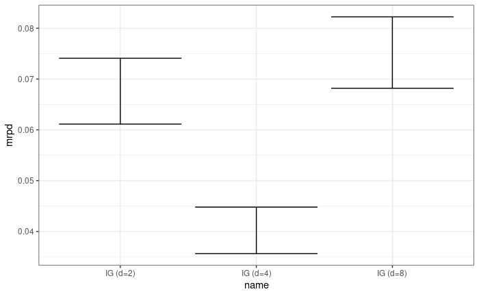

- There are significand differecentes between destruction sizes choices;
- It corroborates with the literature;
- $d = 2$ is too much exploitation and $d = 8$ is too much exploration (further investigation involving mean local optima distances / solution destruction distances)

# Assumption #2: how does it compare to a random approach?

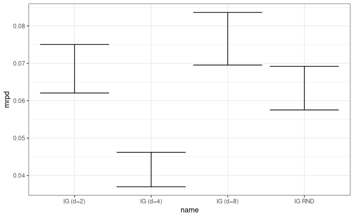

- Random is worse then the average
- Random might imply too much exploration ($d = 8$ has a bigger impact)

# Can a iteration-based reward be used to inform the best destruction size?

Possible adaptation rewards:

```
  IteratedGreedy:
  sol_0 = Init()
  sol_0' = sol_0
  sol_0'' = sol_0
  while (!StoppingCriterion()) :
    d = OperatorSelection(Reward())
    sol_t' = Construction(Destruction(sol_t, d))
    sol_t'' = LocalSearch(sol_t')
    sol_t+1 = Accept(sol_t'', sol_t)
    Feedback(sol_t, sol_t', sol_t'', sol_t+1)´
```

```
  GG = (sol_t+1 - sol_t ) / sol_t
  GL = (sol_t'' - sol_t ) / sol_t
  GG = (sol_t+1 - sol_t') / sol_t'
  GG = (sol_t'' - sol_t') / sol_t'
```

To test the rewards, all destruction sizes are applied and the best perturbation (BP) for each reward is chosen:

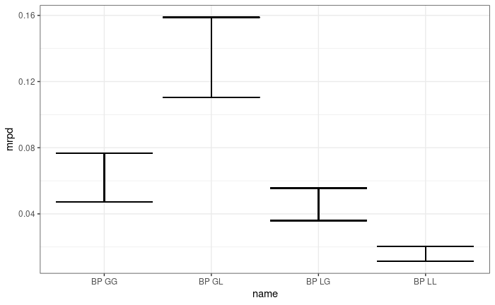

Comparing to the best fixed choice:

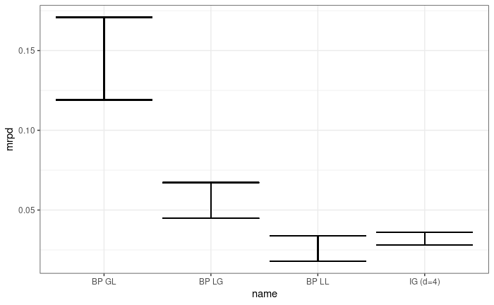

- LL reward is considerably better

# Is there a pattern of destructions sizes over runtime?

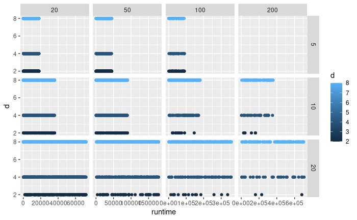

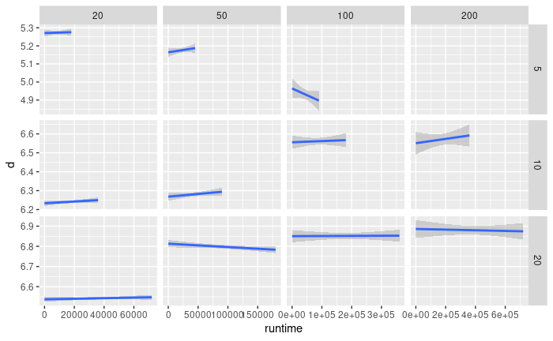

# Can the LL reward be used to inform the best destruction size?

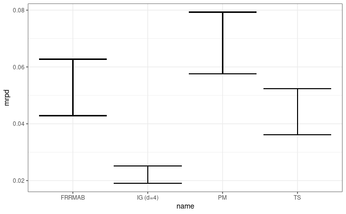

# TODO

- Parameter tunning for AOS strategies
- LinUCB on test instances
- Measure the effect when the number of local search steps is 1 or 0

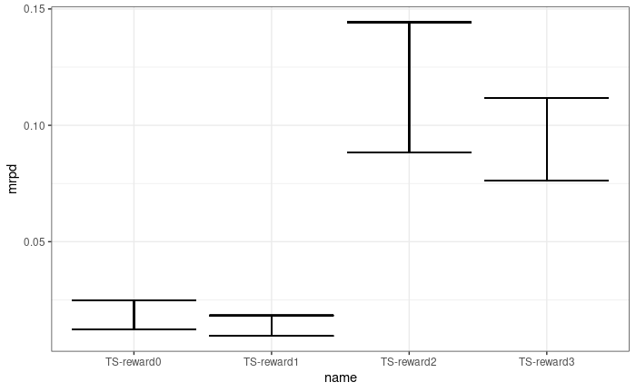

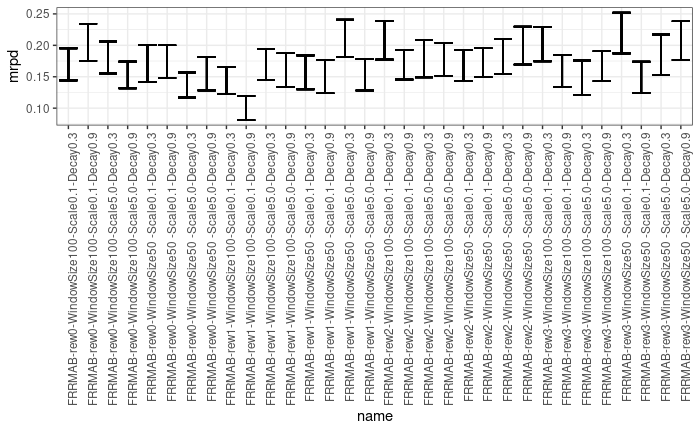

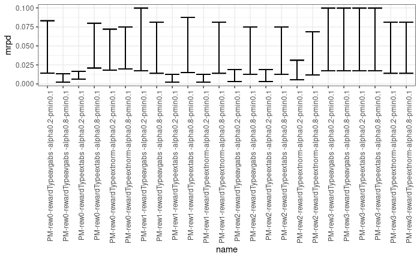

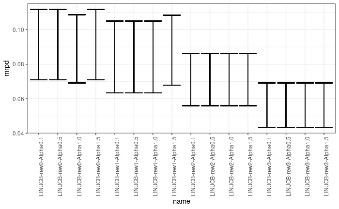

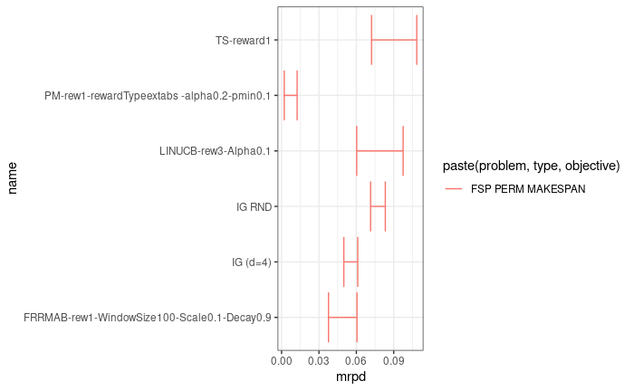

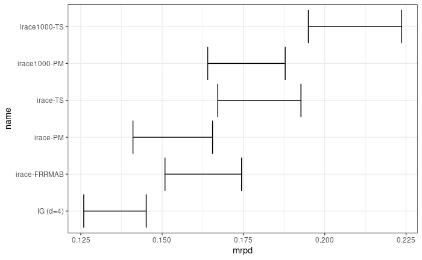

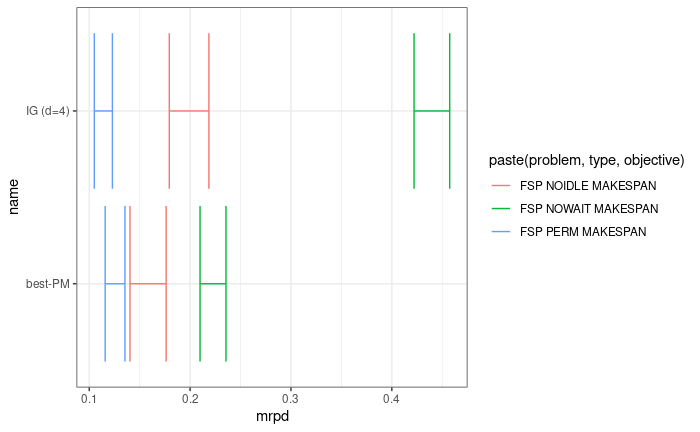